```python
from IPython.display import HTML
HTML('''<script>
code_show=true;
function code_toggle() {
 if (code_show){
 $('div.input').hide();
 } else {
 $('div.input').show();
 }
 code_show = !code_show
}
$( document ).ready(code_toggle);
</script>
<form action="javascript:code_toggle()"><input type="submit" value="Click here to toggle on/off the raw code."></form>''')
```

```python
from IPython.core.display import HTML
HTML("""
<style>
.output_png {
    display: table-cell;
    text-align: center;
    vertical-align: middle;
}
</style>
""")
```

# No Miss Solutions

### Proposed Solution for the "Nomis Solutions" case study from Columbia Business School

Prepared by: Manansala, Dorosan, Edeza, Gonzales, Licong, Marquez

## 1. Introduction

The auto-loan business represents a sizeable amount of consumer credit in the United States. As of April 2019, the dollar value of new loans was estimated at $52.8 Billion[1]. This trend shows no sign of slowing as the forces driving it are inherently intertwined with the country's infrastructure and public policy. A 2019 Frontier Group study described car ownership as the "price of admission to the economy"[2]. Owning a private vehicle is a requirement to be part of American society.

The study notes that individuals who own cars have greater access to jobs than their non-car owning counterparts; this is true even in areas with well-developed public transportation systems. Government spending also facilitates car ownership, with the bulk of government transportation spending going towards highways.

This massive investment in highways helped spur the growth of suburban and exurban areas, normalizing consumers' lifestyles to take their cars to work. Due to these factors, Americans are pushed into car ownership. However, not all Americans can pay a lump sum for their vehicles and therefore require financing. The study found that in 2018, up to 85% of all new cars purchased and 53% of all used cars are financed.

As this set up is likely to continue for the foreseeable future, it would be beneficial for firms to understand how best to meet consumers' financial needs. One such company is e-Car, and one such analytics company helping them is Nomis. e-Car began as the subsidiary of a larger bank and focused on auto loans, conducting their business exclusively online. The company generally gave rates much lower than their competitors and were able to penetrate the market successfully. Using the data e-Car had provided them, Nomis has been working to create a model and a data-driven strategy to help e-Car further improve its business.

## 2. Problem Statement and Rationale

The primary objective of the team is to build a data-driven strategy which optimizes the interest rates offered by e-Car to increase new financing acceptance rates.

Specifically, the team pursued the following more specific objectives:

1. Assess and analyze e-Car's current customer segments and pricing,
2. Perform a statistical comparison between e-Car's rates and its competitors,
3. Build a model to classify and predict customer acceptance of rate offers, and
4. Determine necessary adjustments to e-Car's loan offers to minimize rejection rates and maximize profits.

## 3. Data Description and Processing

##### Loading the Dataset

```python
import pandas as pd
import numpy as np
import seaborn as sns
import matplotlib.pyplot as plt
from sklearn.decomposition import PCA
from scipy.cluster.hierarchy import fcluster
from tqdm import tqdm
import re
plt.style.use('seaborn')
```

```python
df = pd.read_excel('src/NomisB.xlsx')
df.head()
```

|  | Tier | FICO | Approve Date | Term | Amount | Previous Rate | Car Type | Competition rate | Outcome | Rate | Cost of Funds | Partner Bin |
| --- | --- | --- | --- | --- | --- | --- | --- | --- | --- | --- | --- | --- |
| 0 | 1 | 743 | 2002-07-01 | 36 | 19100.00 |  | N | 4.95 | 1 | 4.85 | 1.8388 | 1 |
| 1 | 1 | 752 | 2002-07-01 | 60 | 36460.08 |  | N | 5.65 | 1 | 5.49 | 1.8388 | 1 |
| 2 | 1 | 778 | 2002-07-01 | 48 | 12000.00 |  | U | 5.85 | 1 | 5.85 | 1.8388 | 3 |
| 3 | 2 | 724 | 2002-07-01 | 60 | 19290.00 |  | N | 5.65 | 1 | 5.39 | 1.8388 | 3 |
| 4 | 2 | 700 | 2002-07-01 | 72 | 24461.12 |  | N | 6.25 | 1 | 6.99 | 1.8388 | 3 |

```python
df.describe()
```

|  | Tier | FICO | Term | Amount | Competition rate | Outcome | Rate | Cost of Funds | Partner Bin |
| --- | --- | --- | --- | --- | --- | --- | --- | --- | --- |
| count | 208085.000000 | 208085.000000 | 208085.000000 | 208085.000000 | 208085.000000 | 208085.000000 | 208085.000000 | 208085.000000 | 208085.000000 |
| mean | 1.927304 | 726.731408 | 56.809016 | 26009.516146 | 4.807078 | 0.220040 | 5.623049 | 1.328819 | 2.029671 |
| std | 1.051022 | 44.783564 | 11.204103 | 11108.799130 | 0.586149 | 0.414274 | 1.546978 | 0.278054 | 0.911062 |
| min | 1.000000 | 587.000000 | 36.000000 | 5.000000 | 2.990000 | 0.000000 | 2.450000 | 1.020000 | 1.000000 |
| 25% | 1.000000 | 692.000000 | 48.000000 | 17800.000000 | 4.390000 | 0.000000 | 4.490000 | 1.110000 | 1.000000 |
| 50% | 2.000000 | 726.000000 | 60.000000 | 25000.000000 | 4.790000 | 0.000000 | 5.090000 | 1.262500 | 2.000000 |
| 75% | 3.000000 | 762.000000 | 60.000000 | 33000.000000 | 5.190000 | 0.000000 | 6.390000 | 1.418800 | 3.000000 |
| max | 4.000000 | 854.000000 | 72.000000 | 100000.000000 | 6.450000 | 1.000000 | 15.530000 | 2.127000 | 3.000000 |

##### Cleaning the data

```python
df['Previous Rate'] = df['Previous Rate'].replace(r'^\s+$', np.nan, regex=True)
df[['Tier', 'Partner Bin']] = df[['Tier', 'Partner Bin']].astype(str)
df.rename(columns={'Car  Type': 'Car Type'}, inplace=True)
df.head()
```

|  | Tier | FICO | Approve Date | Term | Amount | Previous Rate | Car Type | Competition rate | Outcome | Rate | Cost of Funds | Partner Bin |
| --- | --- | --- | --- | --- | --- | --- | --- | --- | --- | --- | --- | --- |
| 0 | 1 | 743 | 2002-07-01 | 36 | 19100.00 | NaN | N | 4.95 | 1 | 4.85 | 1.8388 | 1 |
| 1 | 1 | 752 | 2002-07-01 | 60 | 36460.08 | NaN | N | 5.65 | 1 | 5.49 | 1.8388 | 1 |
| 2 | 1 | 778 | 2002-07-01 | 48 | 12000.00 | NaN | U | 5.85 | 1 | 5.85 | 1.8388 | 3 |
| 3 | 2 | 724 | 2002-07-01 | 60 | 19290.00 | NaN | N | 5.65 | 1 | 5.39 | 1.8388 | 3 |
| 4 | 2 | 700 | 2002-07-01 | 72 | 24461.12 | NaN | N | 6.25 | 1 | 6.99 | 1.8388 | 3 |

## 4. Exploratory Data Analysis

### 4.1. Distribution of Interest Rates Cost of Funds

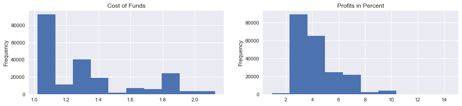

```python
fig, ax = plt.subplots(nrows=1, ncols=2, figsize=(15,3))
df['Rate Profit'] = df['Rate'] - df['Cost of Funds']
df['Cost of Funds'].plot.hist(ax=ax[0]);
df['Rate Profit'].plot.hist(ax=ax[1]);
ax[0].set_title("Cost of Funds");
ax[1].set_title("Profits in Percent");
```

##### Insight

1. The distribution of the `Cost of Funds` are skewed to the right (lower cost of funds). This is good for the customers, but this can still be improved.
2. The distribution of the `Rate Profits` which is the profit of Nomis in Percent is also skewed to the right. However, it has a large variance that reaches to about 10% profits.

### 4.2. Customer Classification

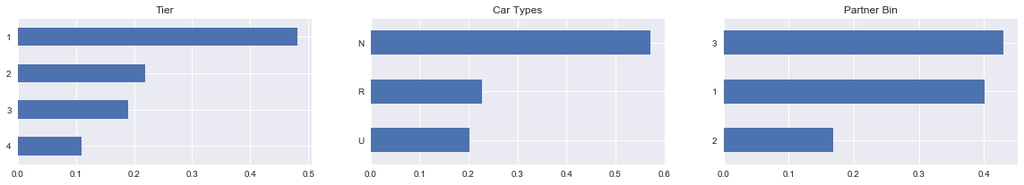

```python
fig, ax = plt.subplots(nrows=1, ncols=3, figsize=(20,3))
df['Tier'].value_counts(normalize=True).sort_values().plot.barh(ax=ax[0]);
df['Car Type'].value_counts(normalize=True).sort_values().plot.barh(ax=ax[1]);
df['Partner Bin'].value_counts(normalize=True).sort_values().plot.barh(ax=ax[2]);
ax[0].set_title('Tier')
ax[1].set_title('Car Types')
ax[2].set_title('Partner Bin');
```

##### Insight

1. The biggest market are in `Tier 1`, `New Financing`, and `Other Partners & Direct Auto Finance Company`

### 4.3. Outcome per Customer Classification

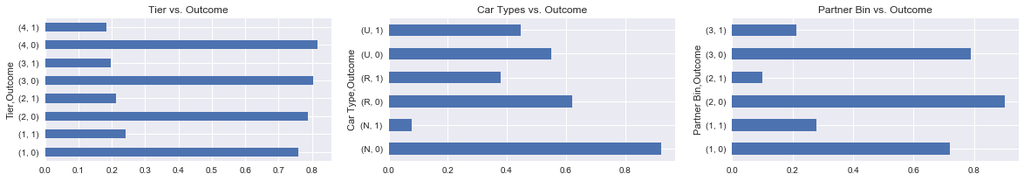

```python
fig, ax = plt.subplots(1,3, figsize=(20,3))
df.groupby('Tier')['Outcome'].value_counts(normalize=True).plot.barh(ax=ax[0]);
df.groupby('Car Type')['Outcome'].value_counts(normalize=True).plot.barh(ax=ax[1]);
df.groupby('Partner Bin')['Outcome'].value_counts(normalize=True).plot.barh(ax=ax[2]);
ax[0].set_title('Tier vs. Outcome')
ax[1].set_title('Car Types vs. Outcome')
ax[2].set_title('Partner Bin vs. Outcome');
```

### 4.4. Profits and Opportunity Losses

```python
df['Ratio'] = df['Competition rate'] / df['Rate']
df['Profits'] = df['Amount'] * (df['Rate'] - df['Cost of Funds'])
accepted_loans = df[df.Outcome == 1]
cancelled_loans = df[df.Outcome == 0]
```

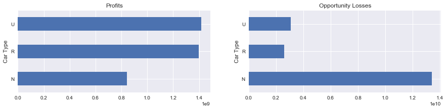

```python
fig, ax = plt.subplots(1,2, figsize=(15,3))
accepted_loans.groupby(['Car Type'])['Profits'].sum().plot.barh(ax=ax[0]);
cancelled_loans.groupby(['Car Type'])['Profits'].sum().plot.barh(ax=ax[1]);
ax[0].set_title('Profits')
ax[1].set_title('Opportunity Losses');
```

##### Insight

1. Most of e-Car's profit comes from the `Used Financing` and `Refinancing` segment.
2. The firm struggles with the `New Financing` segment. When analyzing the amount of potential profits lost per segment, we see that the amount lost in the `New Financing` segment dwarfs the other two.

### 4.5. Is ECar Cheaper than Competitors (Rate)

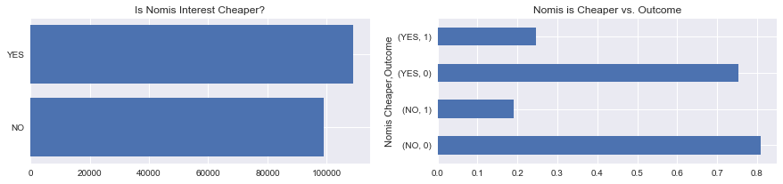

```python
fig, ax = plt.subplots(1,2, figsize=(15,3))
df['Nomis Cheaper'] = np.where(df['Competition rate'] >= df['Rate'], "YES", "NO")
names, counts = np.unique(df['Nomis Cheaper'], return_counts=True)
ax[0].barh(names, counts)
df.groupby('Nomis Cheaper')['Outcome'].value_counts(normalize=True).plot.barh(ax=ax[1]);
ax[0].set_title("Is Nomis Interest Cheaper?");
ax[1].set_title("Nomis is Cheaper vs. Outcome");
```

##### Insight

1. There are more accepted accounts in which the rates are cheaper compared to competitors.
2. The gap between eCar is cheaper and the accepted loans is insignificant.
3. There are still more loans that are not accepted by clients whether rate is cheaper or not.

### 4.6. New Financing customer segment

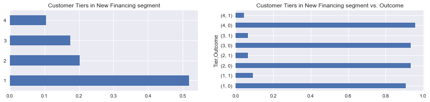

```python
fig, ax = plt.subplots(1,2, figsize=(15,3))
df[df['Car Type']=='N']['Tier'].value_counts(normalize=True).plot.barh(ax=ax[0]);
df[df['Car Type']=='N'].groupby(['Tier'])['Outcome'].value_counts(normalize=True).plot.barh(ax=ax[1]);
ax[0].set_title("Customer Tiers in New Financing segment");
ax[1].set_title("Customer Tiers in New Financing segment vs. Outcome");
```

##### Insight

1. The acceptance rates of Tier 1 customers are higher than that of the other tiers. However, the difference is not significant.

## 5. Methodology

The exploratory data analysis showed the biggest opportunity in the `New Financing` segment. The team focused on this segment. Specifically, by finding a way to convert those who decline the loan offer.

The team implemented the following steps:

1. Create models to classify and predict whether a client will accept or decline a loan offer with the following features:

## 6. Models Developed

**Annual Percentage Rate (APR) Recommender** \ The created model from before was then used to identify the rate to which the outcome will change for the rejected loan accounts. The algorithm updates the rate for each loan account while keeping other features the same as the original account, then the data is fed to the model to check the outcome.

Variations:

The predictive model built was implemented in two approaches:

> i. Without segmentation \ ii. With segmentation according to Tiers

### 6.1. Model A: Predicting Outcome with Rate, Term, Amount, and Competition rate as Features

```python
df['Previous Rate'] = df['Previous Rate'].replace(r'^\s+$', np.nan, regex=True)
df[['Tier', 'Partner Bin']] = df[['Tier', 'Partner Bin']].astype(str)
df.rename(columns={
    'Car  Type': 'Car Type'
}, inplace=True)
```

```python
new_financing = df[df['Car Type'] == 'N']
rejects_all_N = new_financing[new_financing.Outcome == 0]
```

```python
pcc = ((new_financing[new_financing.Outcome == 1].shape[0]/new_financing.shape[0]) ** 2 +
       (new_financing[new_financing.Outcome == 0].shape[0]/new_financing.shape[0]) ** 2)
print('PCC: ', pcc)
print('1.25PCC: ', 1.25 * pcc)
```

```
PCC:  0.8578941406078724
1.25PCC:  1.0723676757598404
```

```python
from sklearn.model_selection import train_test_split

X = new_financing[['Rate', 'Term', 'Amount', 'Competition rate']]
y = new_financing[['Outcome']]
X_train, X_test, y_train, y_test = train_test_split(X, y, test_size=0.25, random_state=200)
```

```python
from sklearn.ensemble import GradientBoostingClassifier

gbc = GradientBoostingClassifier(learning_rate=0.12, max_depth=4, n_estimators=300, random_state=143)
gbc.fit(X_train, y_train.Outcome.values.reshape(-1, 1).flatten())

print(gbc.score(X_train, y_train))
print(gbc.score(X_test, y_test))
```

```
0.9355163840795574
0.9314295313287418
```

```python
idx = y_test[y_test.Outcome == 0].index
rejects = new_financing.loc[idx]
rejects.head()
```

|  | Tier | FICO | Approve Date | Term | Amount | Previous Rate | Car Type | Competition rate | Outcome | Rate | Cost of Funds | Partner Bin | Rate Profit | Ratio | Profits | Nomis Cheaper |
| --- | --- | --- | --- | --- | --- | --- | --- | --- | --- | --- | --- | --- | --- | --- | --- | --- |
| 50041 | 3 | 696 | 2002-07-30 | 36 | 17269.00 | NaN | N | 4.75 | 0 | 6.29 | 1.8188 | 3 | 4.4712 | 0.755167 | 77213.1528 | NO |
| 198663 | 1 | 753 | 2004-09-26 | 60 | 37000.00 | NaN | N | 4.39 | 0 | 4.39 | 1.8400 | 3 | 2.5500 | 1.000000 | 94350.0000 | YES |
| 109777 | 3 | 674 | 2003-07-03 | 48 | 50000.00 | NaN | N | 3.99 | 0 | 5.15 | 1.1175 | 3 | 4.0325 | 0.774757 | 201625.0000 | NO |
| 150712 | 2 | 703 | 2003-12-26 | 72 | 29999.99 | NaN | N | 5.19 | 0 | 5.99 | 1.1400 | 2 | 4.8500 | 0.866444 | 145499.9515 | NO |
| 120221 | 1 | 758 | 2003-08-03 | 60 | 21500.00 | NaN | N | 3.99 | 0 | 4.39 | 1.1125 | 1 | 3.2775 | 0.908884 | 70466.2500 | NO |

```python
total_profit = []
for no in tqdm(range(rejects.shape[0])):
    test_rate = rejects.iloc[no, :].copy()
    competitor = test_rate['Competition rate']
    cofi = test_rate['Cost of Funds'] + 2.0
    curr_rate = test_rate.Rate
    reco_rate = cofi
    flipped_ = False
    new_amount = test_rate.Amount
    old_amount = test_rate.Amount
    for rate in np.arange(cofi, curr_rate, 0.01):
        test_rate.Rate = rate
        test_rate.Amount = old_amount
        X = test_rate[['Rate', 'Term', 'Amount', 'Competition rate']].to_frame().T
        predict = gbc.predict(X)
        if predict == 1 and rate >= reco_rate:
            new_amount = test_rate.Amount
            reco_rate = rate
            flipped_ = True
    if flipped_:
        total_profit.append(new_amount * (reco_rate-(cofi - 2)) - new_amount)
#         print(no, cofi - 2, curr_rate, reco_rate, old_amount, new_amount)
print('total profit: ', sum(total_profit))
```

```
total profit:  912992332.4390017
```

#### Results

Model A successfully predicted if customers will either accept or reject an offered rate at 93% accuracy. This and all the models discussed in this paper used the Gradient Boosting Classifier algorithm available in the sci-kit learn library. Parameters used for Model A, are:

▪ Learning rate: 0.12 \ ▪ Maximum depth: 4 \ ▪ Number of estimators: 300

### 6.2. Model B: Predicting Outcome with Additional Features

```python
from sklearn.model_selection import GridSearchCV
from sklearn.ensemble import GradientBoostingClassifier
from sklearn.preprocessing import MinMaxScaler
mm_scaler = MinMaxScaler()
```

```python
nf = df[df['Car Type']=='N']
use_cols = ['Rate', 'Term', 'Competition rate', 'Cost of Funds', 'Partner Bin', 'Amount', 'FICO']
X = nf[use_cols]
y = nf['Outcome']
```

```python
X_scaled = mm_scaler.fit_transform(X)
```

```python
from sklearn.model_selection import train_test_split
X_train, X_test, y_train, y_test = train_test_split(X, y, test_size=0.25)
```

```python
%%time
learning_rate = [0.24, 0.11, 0.001]
n_estimators = [400]
max_depth = [4]

param_grids = {'learning_rate': learning_rate,
               'n_estimators' : n_estimators,
               'max_depth' : max_depth
              }
mod = GradientBoostingClassifier()
gs_cv = GridSearchCV(mod, param_grids, n_jobs=-1).fit(X_train, y_train)
print(gs_cv.best_params_)

print("Training accuracy : ", gs_cv.score(X_train, y_train))
print("Test accuracy : ", gs_cv.score(X_test, y_test))
```

```
{'learning_rate': 0.11, 'max_depth': 4, 'n_estimators': 400}
Training accuracy :  0.9391336483974287
Test accuracy :  0.9326726020493868
Wall time: 4min 6s
```

```python
%%time
learning_rate = [0.24, 0.11, 0.001]
n_estimators = [400, 1000]
max_depth = [4, 5, 6]

param_grids = {'learning_rate': learning_rate,
               'n_estimators' : n_estimators,
               'max_depth' : max_depth
              }
mod = GradientBoostingClassifier()
gs_cv = GridSearchCV(mod, param_grids, n_jobs=-1).fit(X_train, y_train)
print(gs_cv.best_params_)

print("Training accuracy : ", gs_cv.score(X_train, y_train))
print("Test accuracy : ", gs_cv.score(X_test, y_test))
```

```
{'learning_rate': 0.11, 'max_depth': 4, 'n_estimators': 1000}
Training accuracy :  0.9487871525522431
Test accuracy :  0.9326390055434235
Wall time: 43min 44s
```

```python
%%time
use_cols = ['Rate', 'Term', 'Competition rate', 'Cost of Funds', 'Partner Bin', 'Amount', 'FICO']
X = nf[use_cols]
y = nf['Outcome']
X = mm_scaler.fit_transform(X)

from sklearn.model_selection import train_test_split
X_train, X_test, y_train, y_test = train_test_split(X, y, test_size=0.25)

mod = GradientBoostingClassifier(learning_rate=0.11, max_depth=4, n_estimators=400)
mod.fit(X_train, y_train)
print("Training accuracy : ", mod.score(X_train, y_train))
print("Test accuracy : ", mod.score(X_test, y_test))
```

```
Training accuracy :  0.9397383922771967
Test accuracy :  0.9308583907273643
Wall time: 44.2 s
```

```python
%%time
use_cols = ['Rate', 'Term', 'Competition rate', 'Cost of Funds', 'Partner Bin', 'Amount', 'FICO']
X = nf[use_cols]
y = nf['Outcome']
# X_scaled = mm_scaler.fit_transform(X)

from sklearn.model_selection import train_test_split
X_train, X_test, y_train, y_test = train_test_split(X, y, test_size=0.25, random_state=42)

mod = GradientBoostingClassifier(learning_rate=0.11, max_depth=4, n_estimators=400)
mod.fit(X_train, y_train)

print("Training accuracy : ", mod.score(X_train, y_train))
print("Test accuracy : ", mod.score(X_test, y_test))
for i in np.argsort(mod.feature_importances_):
    print(f"{use_cols[i]} : {mod.feature_importances_[i]}")
```

```
Training accuracy :  0.9391560463189016
Test accuracy :  0.9320678649420461
Partner Bin : 0.02449691042912234
Competition rate : 0.02773515457239091
Cost of Funds : 0.07035715400193822
Term : 0.0842461142637474
Rate : 0.10499728627333946
FICO : 0.12254959654683854
Amount : 0.5656177839126231
Wall time: 41.4 s
```

```python
NF = pd.DataFrame()
index = y_test[y_test==0].index
rejects = X_test.loc[index]

index_list = []
cofi_list = []
lower_limit_list = []
curr_rate_list = []
competition_rate_list = []
reco_rate_list = []
amount_list = []
profit_list = []

print(rejects.shape)
for no in tqdm(range(rejects.shape[0])):
    test_rate = rejects.iloc[no, :].copy()
    competitor = test_rate['Competition rate'] # Rate of competition
    cofi = test_rate['Cost of Funds'] + 2.0 # Minimum
    curr_rate = test_rate.Rate
    reco_rate = cofi
    flipped_ = False
    new_amount = test_rate.Amount
    old_amount = test_rate.Amount
    for rate in np.arange(cofi, curr_rate, 0.01):
        test_rate.Rate = rate
        test_rate.Amount = old_amount
        X = test_rate[['Rate', 'Term', 'Competition rate', 'Cost of Funds', 'Partner Bin', 'Amount', 'FICO']].to_frame().T
        predict = mod.predict(X)
        if predict == 1 and rate >= reco_rate:
            new_amount = test_rate.Amount
            reco_rate = rate
            flipped_ = True
    if flipped_:
        index_list.append(no)
        cofi_list.append(cofi - 2.0)
        lower_limit_list.append(cofi)
        curr_rate_list.append(curr_rate)
        competition_rate_list.append(competitor)
        reco_rate_list.append(reco_rate)
        amount_list.append(new_amount)
        profit_list.append(((reco_rate - cofi + 2.0) * new_amount) - new_amount)

NF['Number'] = index_list
NF['Cost of Funds'] = cofi_list
NF['Lower Limit'] = cofi_list
NF['E-car Rate'] = curr_rate_list
NF['Competition Rate'] = competition_rate_list
NF['Recommended Rate'] = reco_rate_list
NF['Loan Amount'] = amount_list
NF['Profit'] = profit_list
NF
```

```
(27445, 7)
```

|  | Number | Cost of Funds | Lower Limit | E-car Rate | Competition Rate | Recommended Rate | Loan Amount | Profit |
| --- | --- | --- | --- | --- | --- | --- | --- | --- |
| 0 | 4 | 1.3613 | 1.3613 | 5.15 | 4.89 | 4.0813 | 20000.00 | 34400.0000 |
| 1 | 6 | 1.3525 | 1.3525 | 5.15 | 4.89 | 3.4225 | 27000.00 | 28890.0000 |
| 2 | 7 | 1.1000 | 1.1000 | 6.09 | 3.85 | 3.4700 | 29999.00 | 41098.6300 |
| 3 | 8 | 1.1200 | 1.1200 | 3.99 | 3.99 | 3.4200 | 18400.00 | 23920.0000 |
| 4 | 10 | 1.8400 | 1.8400 | 8.55 | 4.39 | 3.8600 | 24999.00 | 25498.9800 |
| ... | ... | ... | ... | ... | ... | ... | ... | ... |
| 11429 | 27429 | 1.1200 | 1.1200 | 5.79 | 4.09 | 4.0800 | 19999.99 | 39199.9804 |
| 11430 | 27431 | 1.8200 | 1.8200 | 4.89 | 5.49 | 3.8600 | 65000.00 | 67600.0000 |
| 11431 | 27433 | 1.2738 | 1.2738 | 4.35 | 4.29 | 3.4638 | 42500.00 | 50575.0000 |
| 11432 | 27436 | 1.8100 | 1.8100 | 4.89 | 5.49 | 3.8600 | 35000.00 | 36750.0000 |
| 11433 | 27437 | 1.8106 | 1.8106 | 6.14 | 5.24 | 3.9606 | 20000.00 | 23000.0000 |

11434 rows × 8 columns

```python
NF.to_csv('src/NF.csv')
```

### 6.3. Model C: Predicting Outcome with Additional Features and Tiers

#### 6.3.1. Model C Tier 1

```python
use_cols = ['Rate', 'Term', 'Competition rate', 'Cost of Funds', 'Partner Bin', 'Amount', 'FICO']
X = nf.loc[nf.Tier=="1", use_cols]
y = nf.loc[nf.Tier=="1", 'Outcome']
# X = mm_scaler.fit_transform(X)

from sklearn.model_selection import train_test_split
X_train, X_test, y_train, y_test = train_test_split(X, y, test_size=0.25, random_state=42)

mod = GradientBoostingClassifier(learning_rate=0.11, max_depth=4, n_estimators=400)
mod.fit(X_train, y_train)
print("Training accuracy : ", mod.score(X_train, y_train))
print("Test accuracy : ", mod.score(X_test, y_test))
```

```
Training accuracy :  0.9401528563409474
Test accuracy :  0.9221502590673575
```

```python
for i in np.argsort(mod.feature_importances_):
    print(f"{use_cols[i]} : {mod.feature_importances_[i]}")
```

```
Partner Bin : 0.02451990366337232
Competition rate : 0.02497422435317439
Rate : 0.052367044393229756
FICO : 0.059652345019221426
Term : 0.06414403197785745
Cost of Funds : 0.10870887325818582
Amount : 0.6656335773349589
```

```python
t1 = pd.DataFrame()
index = y_test[y_test==0].index
rejects = X_test.loc[index]

index_list = []
cofi_list = []
lower_limit_list = []
curr_rate_list = []
competition_rate_list = []
reco_rate_list = []
amount_list = []
profit_list = []

print(rejects.shape)
for no in tqdm(range(rejects.shape[0])):
    test_rate = rejects.iloc[no, :].copy()
    competitor = test_rate['Competition rate'] # Rate of competition
    cofi = test_rate['Cost of Funds'] + 2.0 # Minimum
    curr_rate = test_rate.Rate
    reco_rate = cofi
    flipped_ = False
    new_amount = test_rate.Amount
    old_amount = test_rate.Amount
    for rate in np.arange(cofi, curr_rate, 0.01):
        test_rate.Rate = rate
        test_rate.Amount = old_amount
        X = test_rate[['Rate', 'Term', 'Competition rate', 'Cost of Funds', 'Partner Bin', 'Amount', 'FICO']].to_frame().T
        predict = mod.predict(X)
        if predict == 1 and rate >= reco_rate:
            new_amount = test_rate.Amount
            reco_rate = rate
            flipped_ = True
    if flipped_:
        index_list.append(no)
        cofi_list.append(cofi - 2.0)
        lower_limit_list.append(cofi)
        curr_rate_list.append(curr_rate)
        competition_rate_list.append(competitor)
        reco_rate_list.append(reco_rate)
        amount_list.append(new_amount)
        profit_list.append(((reco_rate - cofi + 2.0) * new_amount) - new_amount)

t1['Number'] = index_list
t1['Cost of Funds'] = cofi_list
t1['Lower Limit'] = cofi_list
t1['E-car Rate'] = curr_rate_list
t1['Competition Rate'] = competition_rate_list
t1['Recommended Rate'] = reco_rate_list
t1['Loan Amount'] = amount_list
t1['Profit'] = profit_list
t1
```

```
(14022, 7)
```

|  | Number | Cost of Funds | Lower Limit | E-car Rate | Competition Rate | Recommended Rate | Loan Amount | Profit |
| --- | --- | --- | --- | --- | --- | --- | --- | --- |
| 0 | 0 | 1.7163 | 1.7163 | 4.89 | 4.99 | 4.2563 | 18000.0 | 27720.00 |
| 1 | 8 | 1.3900 | 1.3900 | 5.64 | 5.75 | 4.4300 | 31100.0 | 63444.00 |
| 2 | 12 | 1.8100 | 1.8100 | 4.85 | 5.49 | 4.0200 | 25000.0 | 30250.00 |
| 3 | 15 | 1.1200 | 1.1200 | 4.69 | 4.75 | 4.2400 | 26500.0 | 56180.00 |
| 4 | 16 | 1.3375 | 1.3375 | 3.99 | 3.99 | 3.9175 | 8855.0 | 13990.90 |
| ... | ... | ... | ... | ... | ... | ... | ... | ... |
| 3089 | 13999 | 1.8000 | 1.8000 | 5.23 | 5.24 | 4.2600 | 19000.0 | 27740.00 |
| 3090 | 14012 | 1.8110 | 1.8110 | 4.49 | 4.49 | 4.0110 | 20000.0 | 24000.00 |
| 3091 | 14013 | 1.3750 | 1.3750 | 5.19 | 5.65 | 4.0150 | 27074.0 | 44401.36 |
| 3092 | 14014 | 1.1000 | 1.1000 | 3.85 | 3.85 | 3.4700 | 17445.0 | 23899.65 |
| 3093 | 14017 | 1.6000 | 1.6000 | 5.39 | 5.39 | 4.0200 | 36317.0 | 51570.14 |

3094 rows × 8 columns

```python
## save excel as dataframe
t1.to_csv('src/Tier_1.csv')
```

#### 6.3.2. Model C Tier 2

```python
use_cols = ['Rate', 'Term', 'Competition rate', 'Cost of Funds', 'Partner Bin', 'Amount', 'FICO']
X = nf.loc[nf.Tier=="2", use_cols]
y = nf.loc[nf.Tier=="2", 'Outcome']
# X = mm_scaler.fit_transform(X)

from sklearn.model_selection import train_test_split
X_train, X_test, y_train, y_test = train_test_split(X, y, test_size=0.25, random_state=42)

mod = GradientBoostingClassifier(learning_rate=0.11, max_depth=4, n_estimators=400)
mod.fit(X_train, y_train)
print("Training accuracy : ", mod.score(X_train, y_train))
print("Test accuracy : ", mod.score(X_test, y_test))
for i in np.argsort(mod.feature_importances_):
    print(f"{use_cols[i]} : {mod.feature_importances_[i]}")
```

```
Training accuracy :  0.9610259826782145
Test accuracy :  0.9337108594270487
Partner Bin : 0.023764431700903713
Cost of Funds : 0.07041804828287597
Rate : 0.07524559459220256
FICO : 0.07657846379167356
Competition rate : 0.08015550063432544
Term : 0.08452653636929801
Amount : 0.5893114246287209
```

```python
t2 = pd.DataFrame()
index = y_test[y_test==0].index
rejects = X_test.loc[index]

index_list = []
cofi_list = []
lower_limit_list = []
curr_rate_list = []
competition_rate_list = []
reco_rate_list = []
amount_list = []
profit_list = []

print(rejects.shape)
for no in tqdm(range(rejects.shape[0])):
    test_rate = rejects.iloc[no, :].copy()
    competitor = test_rate['Competition rate'] # Rate of competition
    cofi = test_rate['Cost of Funds'] + 2.0 # Minimum
    curr_rate = test_rate.Rate
    reco_rate = cofi
    flipped_ = False
    new_amount = test_rate.Amount
    old_amount = test_rate.Amount
    for rate in np.arange(cofi, curr_rate, 0.01):
        test_rate.Rate = rate
        test_rate.Amount = old_amount
        X = test_rate[['Rate', 'Term', 'Competition rate', 'Cost of Funds', 'Partner Bin', 'Amount', 'FICO']].to_frame().T
        predict = mod.predict(X)
        if predict == 1 and rate >= reco_rate:
            new_amount = test_rate.Amount
            reco_rate = rate
            flipped_ = True
    if flipped_:
        index_list.append(no)
        cofi_list.append(cofi - 2.0)
        lower_limit_list.append(cofi)
        curr_rate_list.append(curr_rate)
        competition_rate_list.append(competitor)
        reco_rate_list.append(reco_rate)
        amount_list.append(new_amount)
        profit_list.append(((reco_rate - cofi + 2.0) * new_amount) - new_amount)

t2['Number'] = index_list
t2['Cost of Funds'] = cofi_list
t2['Lower Limit'] = cofi_list
t2['E-car Rate'] = curr_rate_list
t2['Competition Rate'] = competition_rate_list
t2['Recommended Rate'] = reco_rate_list
t2['Loan Amount'] = amount_list
t2['Profit'] = profit_list
t2
```

```
(5622, 7)
```

|  | Number | Cost of Funds | Lower Limit | E-car Rate | Competition Rate | Recommended Rate | Loan Amount | Profit |
| --- | --- | --- | --- | --- | --- | --- | --- | --- |
| 0 | 0 | 1.8400 | 1.8400 | 5.39 | 5.49 | 4.4300 | 24459.0 | 38889.81 |
| 1 | 1 | 1.3788 | 1.3788 | 4.95 | 4.89 | 4.1888 | 28000.0 | 50680.00 |
| 2 | 8 | 1.3175 | 1.3175 | 4.35 | 4.39 | 4.1875 | 38842.0 | 72634.54 |
| 3 | 9 | 1.3200 | 1.3200 | 4.85 | 4.49 | 4.1900 | 30000.0 | 56100.00 |
| 4 | 10 | 2.0700 | 2.0700 | 6.39 | 4.39 | 5.4200 | 25000.0 | 58750.00 |
| ... | ... | ... | ... | ... | ... | ... | ... | ... |
| 2415 | 5614 | 1.3250 | 1.3250 | 4.49 | 4.49 | 4.4350 | 27862.0 | 58788.82 |
| 2416 | 5616 | 1.1100 | 1.1100 | 5.79 | 4.29 | 3.4900 | 30000.0 | 41400.00 |
| 2417 | 5619 | 1.1200 | 1.1200 | 4.89 | 4.09 | 4.1900 | 31765.0 | 65753.55 |
| 2418 | 5620 | 1.1000 | 1.1000 | 4.29 | 3.99 | 3.5100 | 19500.0 | 27495.00 |
| 2419 | 5621 | 1.1000 | 1.1000 | 4.29 | 3.49 | 4.0800 | 20908.0 | 41397.84 |

2420 rows × 8 columns

```python
## save excel as dataframe
t2.to_csv('src/Tier_2.csv')
```

#### 6.3.3. Model C Tier 3

```python
use_cols = ['Rate', 'Term', 'Competition rate', 'Cost of Funds', 'Partner Bin', 'Amount', 'FICO']
X = nf.loc[nf.Tier=="3", use_cols]
y = nf.loc[nf.Tier=="3", 'Outcome']
# X = mm_scaler.fit_transform(X)

from sklearn.model_selection import train_test_split
X_train, X_test, y_train, y_test = train_test_split(X, y, test_size=0.25, random_state=42)

mod = GradientBoostingClassifier(learning_rate=0.11, max_depth=4, n_estimators=400)
mod.fit(X_train, y_train)
print("Training accuracy : ", mod.score(X_train, y_train))
print("Test accuracy : ", mod.score(X_test, y_test))
for i in np.argsort(mod.feature_importances_):
    print(f"{use_cols[i]} : {mod.feature_importances_[i]}")
```

```
Training accuracy :  0.9626460634697657
Test accuracy :  0.9358360467343421
Partner Bin : 0.03097761845712336
Competition rate : 0.0649575556309712
Rate : 0.07070089672633052
Cost of Funds : 0.07479300252770438
Term : 0.08060765262825864
FICO : 0.09335429409973119
Amount : 0.5846089799298807
```

```python
t3 = pd.DataFrame()
index = y_test[y_test==0].index
rejects = X_test.loc[index]

index_list = []
cofi_list = []
lower_limit_list = []
curr_rate_list = []
competition_rate_list = []
reco_rate_list = []
amount_list = []
profit_list = []

print(rejects.shape)
for no in tqdm(range(rejects.shape[0])):
    test_rate = rejects.iloc[no, :].copy()
    competitor = test_rate['Competition rate'] # Rate of competition
    cofi = test_rate['Cost of Funds'] + 2.0 # Minimum
    curr_rate = test_rate.Rate
    reco_rate = cofi
    flipped_ = False
    new_amount = test_rate.Amount
    old_amount = test_rate.Amount
    for rate in np.arange(cofi, curr_rate, 0.01):
        test_rate.Rate = rate
        test_rate.Amount = old_amount
        X = test_rate[['Rate', 'Term', 'Competition rate', 'Cost of Funds', 'Partner Bin', 'Amount', 'FICO']].to_frame().T
        predict = mod.predict(X)
        if predict == 1 and rate >= reco_rate:
            new_amount = test_rate.Amount
            reco_rate = rate
            flipped_ = True
    if flipped_:
        index_list.append(no)
        cofi_list.append(cofi - 2.0)
        lower_limit_list.append(cofi)
        curr_rate_list.append(curr_rate)
        competition_rate_list.append(competitor)
        reco_rate_list.append(reco_rate)
        amount_list.append(new_amount)
        profit_list.append(((reco_rate - cofi + 2.0) * new_amount) - new_amount)

t3['Number'] = index_list
t3['Cost of Funds'] = cofi_list
t3['Lower Limit'] = cofi_list
t3['E-car Rate'] = curr_rate_list
t3['Competition Rate'] = competition_rate_list
t3['Recommended Rate'] = reco_rate_list
t3['Loan Amount'] = amount_list
t3['Profit'] = profit_list
t3
```

```
(4895, 7)
```

|  | Number | Cost of Funds | Lower Limit | E-car Rate | Competition Rate | Recommended Rate | Loan Amount | Profit |
| --- | --- | --- | --- | --- | --- | --- | --- | --- |
| 0 | 0 | 1.1200 | 1.1200 | 5.99 | 4.99 | 4.0200 | 25000.0 | 47500.00 |
| 1 | 2 | 1.8375 | 1.8375 | 6.29 | 5.49 | 4.8775 | 20556.0 | 41934.24 |
| 2 | 5 | 1.1200 | 1.1200 | 5.49 | 3.99 | 4.0800 | 23500.0 | 46060.00 |
| 3 | 13 | 1.3400 | 1.3400 | 5.15 | 4.39 | 4.0200 | 24502.0 | 41163.36 |
| 4 | 18 | 1.8400 | 1.8400 | 6.99 | 5.65 | 5.0900 | 17500.0 | 39375.00 |
| ... | ... | ... | ... | ... | ... | ... | ... | ... |
| 1809 | 4883 | 1.1100 | 1.1100 | 5.15 | 3.99 | 5.0900 | 20414.0 | 60833.72 |
| 1810 | 4885 | 1.3400 | 1.3400 | 5.99 | 5.65 | 5.0900 | 52000.0 | 143000.00 |
| 1811 | 4886 | 1.3000 | 1.3000 | 5.15 | 4.49 | 4.8800 | 20195.0 | 52103.10 |
| 1812 | 4889 | 1.3400 | 1.3400 | 5.15 | 4.49 | 4.0200 | 20000.0 | 33600.00 |
| 1813 | 4890 | 1.6860 | 1.6860 | 8.75 | 5.19 | 4.0860 | 9000.0 | 12600.00 |

1814 rows × 8 columns

```python
## save excel as dataframe
t3.to_csv('src/Tier_3.csv')
```

#### 6.3.4. Model C Tier 4

```python
use_cols = ['Rate', 'Term', 'Competition rate', 'Cost of Funds', 'Partner Bin', 'Amount', 'FICO']
X = nf.loc[nf.Tier=="4", use_cols]
y = nf.loc[nf.Tier=="4", 'Outcome']
# X = mm_scaler.fit_transform(X)

from sklearn.model_selection import train_test_split
X_train, X_test, y_train, y_test = train_test_split(X, y, test_size=0.25, random_state=42)

mod = GradientBoostingClassifier(learning_rate=0.11, max_depth=4, n_estimators=400)
mod.fit(X_train, y_train)
print("Training accuracy : ", mod.score(X_train, y_train))
print("Test accuracy : ", mod.score(X_test, y_test))
for i in np.argsort(mod.feature_importances_):
    print(f"{use_cols[i]} : {mod.feature_importances_[i]}")
```

```
Training accuracy :  0.9845194581810364
Test accuracy :  0.9513060303128024
Partner Bin : 0.023051998894212163
Competition rate : 0.048093795548833605
Term : 0.04968222143692622
Rate : 0.0789430315640128
Cost of Funds : 0.08590317027651263
FICO : 0.0905124756436692
Amount : 0.6238133066358333
```

```python
t4 = pd.DataFrame()
index = y_test[y_test==0].index
rejects = X_test.loc[index]

index_list = []
cofi_list = []
lower_limit_list = []
curr_rate_list = []
competition_rate_list = []
reco_rate_list = []
amount_list = []
profit_list = []

print(rejects.shape)
for no in tqdm(range(rejects.shape[0])):
    test_rate = rejects.iloc[no, :].copy()
    competitor = test_rate['Competition rate'] # Rate of competition
    cofi = test_rate['Cost of Funds'] + 2.0 # Minimum
    curr_rate = test_rate.Rate
    reco_rate = cofi
    flipped_ = False
    new_amount = test_rate.Amount
    old_amount = test_rate.Amount
    for rate in np.arange(cofi, curr_rate, 0.01):
        test_rate.Rate = rate
        test_rate.Amount = old_amount
        X = test_rate[['Rate', 'Term', 'Competition rate', 'Cost of Funds', 'Partner Bin', 'Amount', 'FICO']].to_frame().T
        predict = mod.predict(X)
        if predict == 1 and rate >= reco_rate:
            new_amount = test_rate.Amount
            reco_rate = rate
            flipped_ = True
    if flipped_:
        index_list.append(no)
        cofi_list.append(cofi - 2.0)
        lower_limit_list.append(cofi)
        curr_rate_list.append(curr_rate)
        competition_rate_list.append(competitor)
        reco_rate_list.append(reco_rate)
        amount_list.append(new_amount)
        profit_list.append(((reco_rate - cofi + 2.0) * new_amount) - new_amount)

t4['Number'] = index_list
t4['Cost of Funds'] = cofi_list
t4['Lower Limit'] = cofi_list
t4['E-car Rate'] = curr_rate_list
t4['Competition Rate'] = competition_rate_list
t4['Recommended Rate'] = reco_rate_list
t4['Loan Amount'] = amount_list
t4['Profit'] = profit_list
t4
```

[output not shown]

```
(2958, 7)
```

```python
## save excel as dataframe
t4.to_csv('src/Tier_4.csv')
```

## 7. Conclusion and Recommendations

The team found that e-Car's original pricing can be further improved by implementing machine learning models to increase the acceptance rate of the loan offers. Through exploratory analysis, the group was able to find the segment (in terms of loan type) where e-Car was underperforming. This segment also represented the most significant opportunity loss among the three and increasing e-Car's performance in this segment would substantially increase the company’s profits.

The group was able to predict whether a customer would accept or reject an offer using the three predictive models. The group found that those who rejected e-Car's initial offer could still change their mind if the interest rate was lower. By setting a floor interest rate (to ensure profitability), the group was able to pinpoint what these rates were and subsequently compute the profit e-Car could have been making.

The team recommends making a similar approach to the two other segments (i.e., Refinance and Used Finance). In the future, creating new tiers is advised to determine the rate threshold for higher profitability.

## 8.References

[1] Consumer Financial Protection Bureau. 2020. Auto Loans | Consumer Financial Protection Bureau. [online] Available at: https://www.consumerfinance.gov/data-research/consumer-credit-trends/auto-loans/ [Accessed 2 August 2020].

[2] Uspirg.org. 2020. [online] Available at: https://uspirg.org/sites/pirg/files/reports/WEB_USP_Driving-into-debt_Report_021219-v2.pdf [Accessed 5 August 2020].Besbes, O., Chen, D. and Phillips, R., 2014. Nomis Solutions (A & B). Columbia CaseWorks,.

[3] Besbes, O., Chen, D. and Phillips, R., 2014. Nomis Solutions (A & B). Columbia CaseWorks,.

```python
# create HTML version of this notebook
!jupyter nbconvert "No Miss Solutions.ipynb" --no-prompt
```